# STAT385 Lab 4

Jonathan Bonaguro

2/19/2020

# R Markdown Lab

Source: David Dalpiaz’s STAT 3202-Sp19 at Ohio State

# Class Schedule

1. Add a header to your document titled “Class Schedule”
2. Add a bulleted list in that section that lists your Spring 2020 schedule.
- **PS328** - Introduction to Biology and Politics
- **PS396** - International Conflict
- **PS496** - Senior Thesis
- **PSYCH496** - Advanced Topics in Psychology
- **STAT385** - Statistical Programming Methods

# Using R

In this section, add three R “chunks.” Do the following in those chunks:

- **Chunk 1:** Create a vector called x that stores the integers from `1` to `10`. Calculate the standard deviation of this vector.
  - *Hint:* Use the `:` operator.

```r
x <- 1:10
sd(x)
```

```
## [1] 3.02765
```

```r
dpois(5, 3)
```

```
## [1] 0.1008188
```

- **Chunk 3:** Generate a sample of size `100` from a standard normal distribution and store it in a vector named `std_norm`. Calculate the mean of this vector. (Fingers crossed that it is close to zero!)
  - *Hint:* Use the `rnorm()` function.
  - *Note:* For an added bonus (worth no points), set a seed first so that every time you knit this document the “random” result will be the same.

```r
set.seed(385)
std_norm <- rnorm(100, mean = 0, sd = 1)
mean(std_norm)
```

```
## [1] 0.01098816
```

# Simulation Study

In this section, add the following R code in a chunk.

```r
# function that simulates sample means and variance from a poisson distribution
# for various sample sizes and true lambdas
sim_mean_var = function(sample_size = 50, true_lambda = 2) {
  sim_sample = rpois(n = sample_size, lambda = true_lambda)
  c(mean(sim_sample), var(sim_sample))
}

# generate sample means and variances
set.seed(42)
results = replicate(10000, sim_mean_var())
sample_means = results[1, ]
sample_variances = results[2, ]
```

This is code we saw in class for obtaining the empirical distribution of X¯ and S2 when attempting to estimating λ=2 using a sample of size 50 from a Poisson distribution.

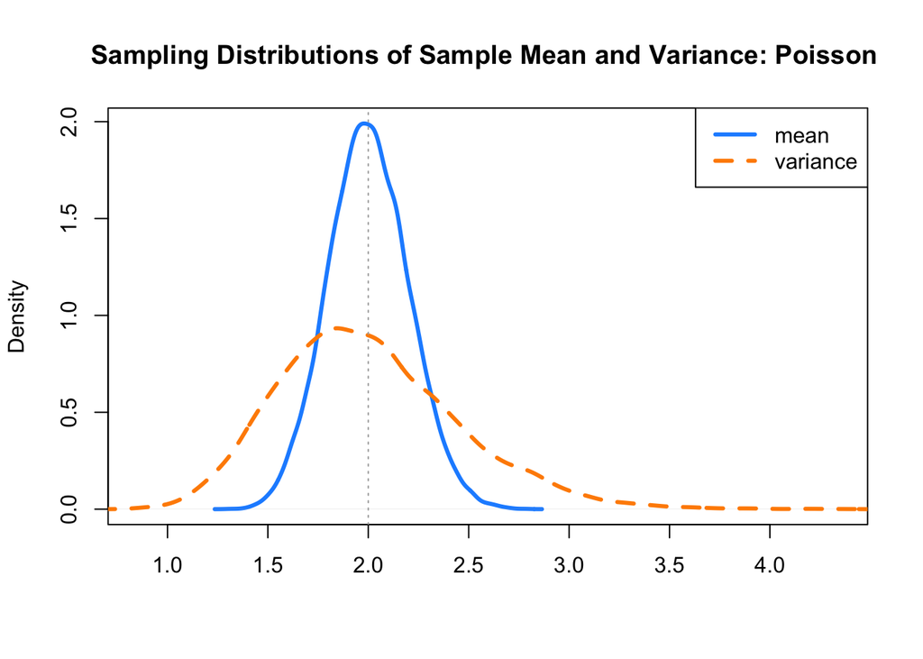

# Objects and Functions

Create another header titled “Objects and Functions.” In that section, recreate the following blockquote:

> “To understand computations in R, two slogans are helpful:
> - Everything that exists is an object.
> - Everything that happens is a function call."  
>   — John Chambers